# Basic introduction of text analysis in R.

Text mining or text analysis, is the process of gaining insights from large collections of unstructured data. It uses natural language processing (NLP) to transform raw (unstructured) data into a normalized, structured form suitable for machine learning (ML) algorithms. Such algorithms can be used to automate tasks such as text classification and clustering, topic modeling, document summation, sentiment analysis, and key-word extraction.

- NLP tasks include: tokenization, lemmatization/stemming, part-of-speech tagging, language detection and identification of semantic relationships.
- Text mining techniques includes:
  - text classification: where text is assigns to predefined categories based on its content; used to identify topics, sentiment, language, etc.
  - text extraction: named-entity-recognition extracts specific pieces of data from text (eg: keywords, prices, company names, etc.)

## Preprocessing

Text data contains characters such as punctuation, stop words, etc., noise that adds little value in understanding the meaning of text but increases the complexity of the analysis. Preprocessing text involves removing this noise in order to simplify our data and analysis. Preprocessing includes the following:

- Tokenization
- Cleansing
- Stemming & Lemmatization

### Tokenization

The first step in text preprocessing is tokenization, which involves breaking text into meaningful elements (token). A token is a unit of analysis such as words, sequences of words (n-grams), entire sentences, symbols or other meaninful elements.

### Cleansing

- normalizing case by converting all letters to lower or upper
- removing punctuations, numbers and white spaces
- removing stop words, sparce terms or specific words

### Stemming & Lemmatization

The goal of both stemming and lemmatization is to reduce related forms of a word to a common base form. (eg: troubled, troubles are reduced to trouble)  
Documents use different forms of a word (eg: organize, organizes, organizing). Also there are families of related words with similar meanings (eg: democracy, democratic, democratization). Often it would be useful for a search for one of these words to return documents that contain another word in the set.

- Stemming uses a more crude approach, that basically chops off letters from the end until the stem is reached. While this works well in many cases, there are many exceptions that require a more sophisticated process. As a result stemming may not result in a real word. There are 2 primary errors in stemming:
  - Over-stemming (false-positives): when 2 words are stemmed from the same root that are of different stems.
  - Under-stemming: (false-negatives): when 2 words are stemmed from the same root that are not of different stems.
- Lemmatization considers a language’s full vocabulary and word context and converts a word to its meaningful base form (lemma). The lemma of ‘was’ is ‘be’, and ‘mice’ is ‘mouse’. Lemmatization results in a real word, but the process can be computationally expensive. Where performance is an issue such as with a large dataset, stemming may be prefered, depending on your application.

#### Stemming example

Here the SnowBall algorithm is used for stemming

```r
library(SnowballC)
library(tidytext)
library(dplyr, warn.conflicts = FALSE)

txt <- c(d1 = "spaCy is great at fast natural language processing.",
         d2 = "The democratic and replublic parties have become so polarized.")

text_df <- tibble(line = 1:2, text = txt)

text_df %>%
  unnest_tokens(word, text) %>%
  mutate(stem = wordStem(word))
```

```
## # A tibble: 17 x 3
##     line word       stem
##    <int> <chr>      <chr>
##  1     1 spacy      spaci
##  2     1 is         i
##  3     1 great      great
##  4     1 at         at
##  5     1 fast       fast
##  6     1 natural    natur
##  7     1 language   languag
##  8     1 processing process
##  9     2 the        the
## 10     2 democratic democrat
## 11     2 and        and
## 12     2 replublic  replubl
## 13     2 parties    parti
## 14     2 have       have
## 15     2 become     becom
## 16     2 so         so
## 17     2 polarized  polar
```

Observe that some of the stemmed words do not result in actual words due to the crude nature of stemming.

#### Lemmatization example

Here is an example that uses the spacyr package which provides an R wrapper around the Python spaCy package. spaCy offers access to the following functionality enabled by the R package.

- parsing texts into tokens or sentences
- lemmatizing tokens
- parsing dependencies (to identify the grammatical structure of the sentence)
- identifying, extracting, or consolidating token sequences that form named entities or noun phrases.

These are tasks used in named-entity recognition (NER), also referred as entity identification or entity extraction. NER is an information extraction (IE) technique that automatically identifies named-entities in a text and classifies them into predefined categories such as: persons, organizations, locations, time, quantities, monetary values, etc.

```r
library("spacyr")
spacy_initialize(model = "en_core_web_sm")

# process documents and obtain a data.table
parsedtxt <- spacy_parse(txt)
parsedtxt
```

```
## # A tibble: 19 x 7
##    doc_id sentence_id token_id token      lemma      pos   entity
##    <chr>        <int>    <int> <chr>      <chr>      <chr> <chr>
##  1 d1               1        1 spaCy      spaCy      PROPN ""
##  2 d1               1        2 is         be         AUX   ""
##  3 d1               1        3 great      great      ADJ   ""
##  4 d1               1        4 at         at         ADP   ""
##  5 d1               1        5 fast       fast       ADJ   ""
##  6 d1               1        6 natural    natural    ADJ   ""
##  7 d1               1        7 language   language   NOUN  ""
##  8 d1               1        8 processing processing NOUN  ""
##  9 d1               1        9 .          .          PUNCT ""
## 10 d2               1        1 The        the        DET   ""
## 11 d2               1        2 democratic democratic ADJ   ""
## 12 d2               1        3 and        and        CCONJ ""
## 13 d2               1        4 replublic  replublic  ADJ   ""
## 14 d2               1        5 parties    party      NOUN  ""
## 15 d2               1        6 have       have       AUX   ""
## 16 d2               1        7 become     become     VERB  ""
## 17 d2               1        8 so         so         ADV   ""
## 18 d2               1        9 polarized  polarized  ADJ   ""
## 19 d2               1       10 .          .          PUNCT ""
```

For the 2 lines of text, we can see how spaCy has parsed the text into tokens with parts of speech (pos) tagging and its base lemma

### Document-Term Matrix

A document-term matrix or term-document matrix describes the frequency of terms that occur in a collection of documents. Many data mining tasks (eg: word frequencies, clustering, classification, association analysis) require such a matrix.

## Demo

Perform some basic text processing and analysis on Twitter data. The demo shows 2 approaches

- Using a document corpus
- The Tidy way using tidyverse

### Libraries

Common libraries

```r
# plotting and pipes
library(ggplot2)
library(dplyr, warn.conflicts = FALSE)
options(dplyr.summarise.inform = FALSE)

# text mining library
suppressPackageStartupMessages(library(tidyverse))
library(tm)
library(tidytext)

# date/time libaray
library(lubridate, warn.conflicts = FALSE)

# stemming libary
library(SnowballC)

# word cloud
library(wordcloud2)
```

### Read twitter data from file and create a corpus

From the last exercise Twitter data was collected using the Twitter api via the R wrapper rtweet and saved to file.

- read the data csv data and filter on just Trump, the focus of analysis
- build a documet corpus

```r
# read as a tibble
twitterDf = read.csv('~/Desktop/GGU/data 104/data/candidates.csv',
                     stringsAsFactors = FALSE)

# filter on trump tweets for analyis
trumpDf = twitterDf  %>%
    filter(is_retweet==FALSE) %>% # remove retweets
    select(screen_name, text) %>%
    filter(screen_name=='realDonaldTrump')

# build a document corpus
trumpCorpus <- Corpus(VectorSource(trumpDf$text))
trumpCorpus
```

```
## <<SimpleCorpus>>
## Metadata:  corpus specific: 1, document level (indexed): 0
## Content:  documents: 1733
```

### Preprocessing

Using the tm package, perform transformations on the corpora to clean the text. There are generalized text cleaning activities such as normalization and stop word removal, however twitter data has additional data (eg: urls, retweets, hashtags, etc) that need to be removed.

```r
# standard cleansing
trumpCorpus <- tm_map(trumpCorpus, tolower)            # normalize case
trumpCorpus <- tm_map(trumpCorpus, removePunctuation)  # remove punctuation
trumpCorpus <- tm_map(trumpCorpus, removeNumbers)      # remove numbers
trumpCorpus <- tm_map(trumpCorpus, stripWhitespace)    # remove white space
trumpCorpus <- tm_map(trumpCorpus, removeWords, stopwords("english")) # remove stopwords

# custom cleansing for twitter data
trumpCorpus <- tm_map(trumpCorpus, removeWords, c('t.co', 'amp')) # remove custom stopwords


# remove patterns via regular expressions
textCleaning <- function(txt){
  gsub("http[[:alnum:]]*",'', txt)
  gsub('http\\S+\\s*', '', txt) # Remove URLs
  gsub('\\b+RT', '', txt)       # Remove RT
  gsub('#\\S+', '', txt)        # Remove Hashtags
  gsub('@\\S+', '', txt)        # Remove Mentions
}
trumpCorpus <- tm_map(trumpCorpus, textCleaning)
```

### Stemming

Use the SnowBall stemming algorithm to stem words in the text and inspect a few rows.

```r
# stem words using SnowBall stemmper
trumpCorpus <- tm_map(trumpCorpus, stemDocument)

# inspect the first three documents
inspect(trumpCorpus[1:3])
```

```
## <<SimpleCorpus>>
## Metadata:  corpus specific: 1, document level (indexed): 0
## Content:  documents: 3
##
## [1] take care peopl wasn’t fault plagu came china
## [2] just don’t see way nanci pelosi cryin’ chuck schumer will will right great american worker wonder usa stimulus primari focus bail poor run high crime democrat citi state
## [3] michell fischbach fischbachmn run congress minnesota strong support brave law enforc second amend famili incred farmer michell complet total endors mn httpstcofhpveb
```

### Document-Term Matrix

Create a TermDocumentMatrix from the cleaned Corpus

```r
# The term document matrix is where each word/term is a row with documents as columns
dtm <- TermDocumentMatrix(trumpCorpus)

# inspect
inspect(dtm )
```

```
## <<TermDocumentMatrix (terms: 4344, documents: 1733)>>
## Non-/sparse entries: 18948/7509204
## Sparsity           : 100%
## Maximal term length: 28
## Weighting          : term frequency (tf)
## Sample             :
##           Docs
## Terms      1258 1591 205 44 588 66 706 772 873 973
##   biden       0    0   0  0   0  0   0   3   2   0
##   democrat    0    0   1  0   0  0   0   0   0   0
##   great       0    0   0  1   0  0   1   0   0   0
##   joe         0    0   1  0   1  0   0   0   0   0
##   just        0    0   0  0   0  1   0   0   0   0
##   peopl       0    0   0  0   1  0   0   0   0   1
##   state       0    0   0  0   0  0   0   0   0   0
##   thank       0    0   0  0   0  0   0   0   0   0
##   vote        0    0   2  0   1  0   0   0   0   0
##   will        0    1   0  0   0  3   0   0   0   0
```

Based on the top terms returned, you may wish to remove some of these, if they don’t add value to your analysis. For example ‘will’ which looks to be a stop word, should probably be removed.

### Create a DocumentTermMatrix from the cleaned Corpus

```r
# The doc term matrix is where each document is a row with words.terms as columns
dtm2 <- DocumentTermMatrix(trumpCorpus, control = list(minWordLength = 2))
inspect(dtm2)
```

```
## <<DocumentTermMatrix (documents: 1733, terms: 4344)>>
## Non-/sparse entries: 18948/7509204
## Sparsity           : 100%
## Maximal term length: 28
## Weighting          : term frequency (tf)
## Sample             :
##       Terms
## Docs   biden democrat great joe just peopl state thank vote will
##   1258     0        0     0   0    0     0     0     0    0    0
##   1591     0        0     0   0    0     0     0     0    0    1
##   205      0        1     0   1    0     0     0     0    2    0
##   44       0        0     1   0    0     0     0     0    0    0
##   588      0        0     0   1    0     1     0     0    1    0
##   66       0        0     0   0    1     0     0     0    0    3
##   706      0        0     1   0    0     0     0     0    0    0
##   772      3        0     0   0    0     0     0     0    0    0
##   873      2        0     0   0    0     0     0     0    0    0
##   973      0        0     0   0    0     1     0     0    0    0
```

Note: Term-document matrices tend to get very big already for normal sized data sets. Therefore function **removeSparseTerms()** can be used to remove sparse terms (i.e., terms occurring only in very few documents). Normally, this reduces the matrix dramatically without losing significant relations inherent to the matrix. The sparse argument to removeSparseTerms(), is the threshold of relative document frequency for a term, above which the term will be removed. It is a value between 0 and 1. Closer to 0 means nearly all values will be retained while closer to 1 means nearly none of the documents will be retained.

```r
inspect (removeSparseTerms(dtm2, .85))
```

```
## <<DocumentTermMatrix (documents: 1733, terms: 1)>>
## Non-/sparse entries: 288/1445
## Sparsity           : 83%
## Maximal term length: 4
## Weighting          : term frequency (tf)
## Sample             :
##       Terms
## Docs   will
##   1063    3
##   1098    6
##   138     3
##   1569    3
##   19      3
##   66      3
##   78      3
##   8       3
##   944     3
##   947     4
```

## Perform Analysis

### Frequent Terms

```r
findFreqTerms(dtm, 5) %>%
  head(20)
```

```
##  [1] "came"     "care"     "china"    "peopl"    "plagu"    "take"
##  [7] "wasn’t"   "american" "citi"     "crime"    "democrat" "don’t"
## [13] "focus"    "great"    "high"     "just"     "nanci"    "pelosi"
## [19] "poor"     "primari"
```

### Word associations

```r
# word associations
findAssocs(dtm, c('fake', 'china', 'democrat'), c(0.50, .30, .30))
```

```
## $fake
## news
## 0.68
##
## $china
##              virus             biden‘             gordon httpstcolmxvsqojzp
##               0.51               0.33               0.33               0.33
##           treasuri                win
##               0.33               0.31
##
## $democrat
## citi  run
## 0.35 0.32
```

### top 50 frequent words with a word frequency of at least 20

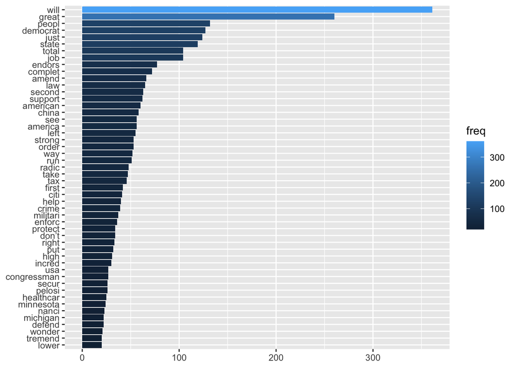

```r
termCount <- rowSums(as.matrix(dtm))  # sums rows
termCount <- subset(termCount, termCount >=20)

df <- data.frame(term = names(termCount), freq = termCount)

df %>%
  head(50) %>%
  ggplot( aes(x = reorder(term, freq), y = freq, fill= freq)) +
    geom_bar(stat = "identity") +
    scale_colour_gradientn(colors = terrain.colors(10)) +
    xlab(NULL) + ylab(NULL) + coord_flip()
```

### Word cloud, top 200 words

```r
df   %>%
  head(200)   %>%
  wordcloud2( color = "random-dark", backgroundColor = "white")
```

[interactive chart not shown]

## using tidytext

An advantage of tidytext format is that once the text has been tidy-ed, regular R functions can be used to analyze it instead of the specialized functions necessary to analyze a Corpus object. We can perform some of the same analyis as above the tidy way as follows.

### tidying data

```r
# convert dataframe to tibble
tidy_df <- as_tibble(trumpDf$text)

# the text is itself a dataframe? modify the text column to pull out the text value
tidy_df <- tidy_df %>%
  mutate(text =  tidy_df$value)  %>%
  select(-value)
tidy_df
```

```
## # A tibble: 1,733 x 1
##    text
##    <chr>
##  1 ....Should take care of our people. It wasn’t their fault that the Plague ca…
##  2 Just don’t see any way Nancy Pelosi and Cryin’ Chuck Schumer will be willing…
##  3 Michelle Fischbach (@FischbachMN7) is running for Congress in Minnesota. She…
##  4 .@JimOberweis will be a terrific Congressman for Illinois! A successful busi…
##  5 Eric Esshaki (@EsshakiCongress) will be a tremendous advocate for Michigan a…
##  6 Paul Junge (@VotePaulJunge) will be a great Congressman for Michigan! He hel…
##  7 Jim Marchant (@VoteJimMarchant) will be an incredible Congressman for Nevada…
##  8 .@DanRodimer will be an incredible Congressman for Nevada! A former professi…
##  9 Congresswoman @EliseStefanik is doing a terrific job for New York! She fierc…
## 10 Congressman @BryanSteil is doing a great job for the people of Wisconsin! He…
## # … with 1,723 more rows
```

### break text into tokens using tidytext

The unnest_tokens() function, part of tidytext, performs some automatic text cleaning

- The unnest_tokens() function takes 2 arguments:
  - the name of the column where the unique word will be stored
  - the column name from the data frame containing the text
- Converts each word in text to lowercase,
- Punctuation is removed: eg: periods, commas etc

```r
tidy_df <- tidy_df %>%
    unnest_tokens(word, text) %>%
    count(word) %>%
    arrange(desc(n))

tidy_df
```

```
## # A tibble: 5,448 x 2
##    word      n
##    <chr> <int>
##  1 the    1371
##  2 t.co   1109
##  3 https  1106
##  4 and     902
##  5 to      833
##  6 of      576
##  7 a       564
##  8 in      528
##  9 is      425
## 10 for     419
## # … with 5,438 more rows
```

### text cleaning

- remove urls, numbers, stop words
- stemming

```r
tidy_df = tidy_df[-grep("http\\S+\\s*", tidy_df$word),] # Remove URLs
tidy_df = tidy_df[-grep("\\b\\d+\\b", tidy_df$word),]   # remove all numeric digits
tidy_df = tidy_df[-grep('t.co',  tidy_df$word),]
tidy_df = tidy_df[-grep('amp',  tidy_df$word),]

tidy_df = tidy_df  %>%
  anti_join(stop_words) # stop words

tidy_df = tidy_df %>%
  mutate(stem = wordStem(word))
  #mutate_at("word", funs(wordStem((.), language="en")))  # stemming

#tidy_df %>%
#  count(stem) %>%
#  arrange(desc(n))

tidy_df
```

```
## # A tibble: 4,837 x 3
##    word        n stem
##    <chr>   <int> <chr>
##  1 biden     195 biden
##  2 joe       151 joe
##  3 vote      149 vote
##  4 people    132 peopl
##  5 news      101 new
##  6 fake      100 fake
##  7 maga       85 maga
##  8 total      81 total
##  9 trump      81 trump
## 10 country    78 countri
## # … with 4,827 more rows
```

### plot top 50 terms having a frequency of 20 or higher

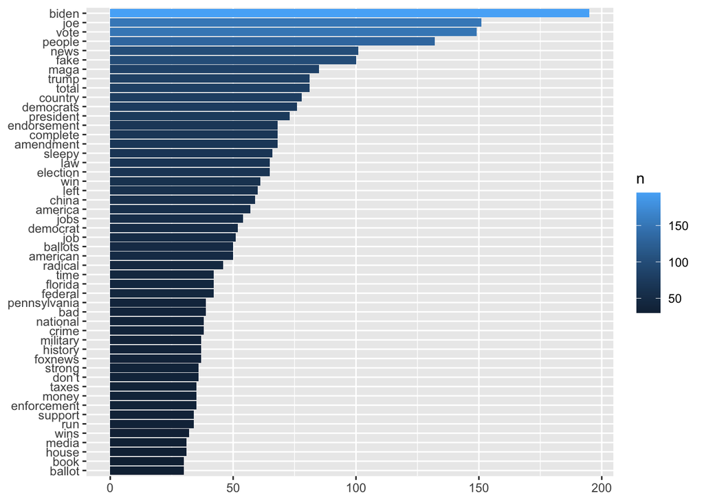

```r
tidy_df = tidy_df%>%
    filter(n >= 20)  %>%
    mutate(word = reorder(word, n)) %>%
    head(50)

  #ggplot(tidy_df, aes(word, n, fill= n)) +
  ggplot(tidy_df, aes(x = reorder(word, n), y = n, fill= n)) +
    geom_bar(stat = "identity") +
    scale_colour_gradientn(colors = terrain.colors(10)) +
    xlab(NULL) + ylab(NULL) + coord_flip()
```

### Top bi-grams

A bigram is an n-gram for n=2. Here we show the top (15) 2 word phrases.

```r
df = trumpDf %>%
  # filter out other urls, etc
  filter(!str_detect(text, 'http\\S+\\s*'),
         !str_detect(text, 'amp'),
         !str_detect(text, 't.co')) %>%
  # get bi-grams
  unnest_tokens(bigram, text, token = "ngrams", n = 2) %>%
  # separate bi-grams into different columns
  separate(bigram, c("word1", "word2"), sep = " ")

bigrams = df  %>%
  filter(!word1 %in% stop_words$word) %>% # filter out stop words
  filter(!word2 %in% stop_words$word) %>%
  count(word1, word2, sort = TRUE) %>%
  head(15)

bigrams
```

```
## # A tibble: 15 x 3
##    word1      word2          n
##    <chr>      <chr>      <int>
##  1 joe        biden         43
##  2 sleepy     joe           39
##  3 fake       news          26
##  4 radical    left          19
##  5 stock      market        14
##  6 supreme    court         14
##  7 federal    government    13
##  8 00         p.m           12
##  9 white      house         12
## 10 nancy      pelosi        11
## 11 approval   rating        10
## 12 bus        service       10
## 13 china      virus         10
## 14 national   guard         10
## 15 republican party         10
```

### Visualizing a network of bigrams with ggraph

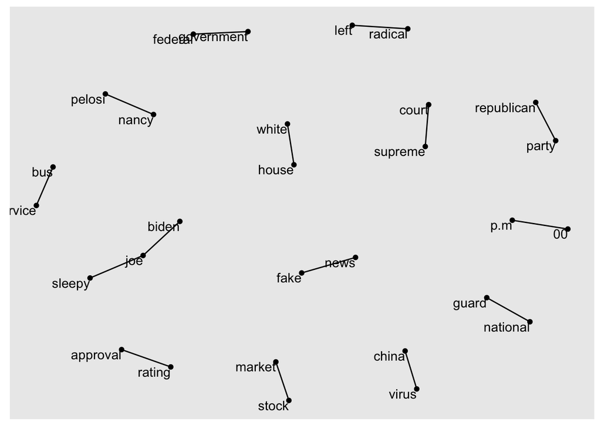

```r
library(ggraph)
set.seed(2017)

ggraph(bigrams, layout = "fr") +
  geom_edge_link() +
  geom_node_point() +
  geom_node_text(aes(label = name), vjust = 1, hjust = 1)
```

### References

- https://nlp.stanford.edu/IR-book/html/htmledition/stemming-and-lemmatization-1.html
- https://blogs.harvard.edu/dlarochelle/2014/03/30/the-problems-with-stemmming-a-practical-example/
- https://smltar.com/tokenization.html#building-your-own-tokenizer
- https://cran.r-project.org/web/packages/tm/vignettes/tm.pdf
- https://www.tidytextmining.com/ngrams.html